# data_621_hw_4

Jimmy Ng

4/23/2020

## Introduction

```r
# load packages
if(!require(pacman)){install.packages("pacman"); require(pacman)}
```

```r
packages <- c('tidyverse', 'sqldf', 'broom', 'caret', 'kableExtra', 'janitor', 'Hmisc', 'MASS', 'corrplot', 'Metrics')
pacman::p_load(char = packages)
```

## EDA

```r
# read data
dfTrain <- read.csv("insurance_training_data.csv", header = TRUE)
dfEval <- read.csv("insurance-evaluation-data.csv", header = TRUE)

# check dim
dim(dfTrain); dim(dfEval)
```

```
## [1] 8161   26
## [1] 2141   26
```

```r
# are they compatible?
if(!any(names(dfTrain) == names(dfEval))){print("the two data sets are different, please check for consistency")}

# clean names
dfTrain <- dfTrain %>% janitor::clean_names()
dfEval <- dfEval %>% janitor::clean_names()

# head
head(dfTrain) %>% kable()
```

| index | target_flag | target_amt | kidsdriv | age | homekids | yoj | income | parent1 | home_val | mstatus | sex | education | job | travtime | car_use | bluebook | tif | car_type | red_car | oldclaim | clm_freq | revoked | mvr_pts | car_age | urbanicity |
| --- | --- | --- | --- | --- | --- | --- | --- | --- | --- | --- | --- | --- | --- | --- | --- | --- | --- | --- | --- | --- | --- | --- | --- | --- | --- |
| 1 | 0 | 0 | 0 | 60 | 0 | 11 | $67,349 | No | $0 | z_No | M | PhD | Professional | 14 | Private | $14,230 | 11 | Minivan | yes | $4,461 | 2 | No | 3 | 18 | Highly Urban/ Urban |
| 2 | 0 | 0 | 0 | 43 | 0 | 11 | $91,449 | No | $257,252 | z_No | M | z_High School | z_Blue Collar | 22 | Commercial | $14,940 | 1 | Minivan | yes | $0 | 0 | No | 0 | 1 | Highly Urban/ Urban |
| 4 | 0 | 0 | 0 | 35 | 1 | 10 | $16,039 | No | $124,191 | Yes | z_F | z_High School | Clerical | 5 | Private | $4,010 | 4 | z_SUV | no | $38,690 | 2 | No | 3 | 10 | Highly Urban/ Urban |
| 5 | 0 | 0 | 0 | 51 | 0 | 14 |  | No | $306,251 | Yes | M | <High School | z_Blue Collar | 32 | Private | $15,440 | 7 | Minivan | yes | $0 | 0 | No | 0 | 6 | Highly Urban/ Urban |
| 6 | 0 | 0 | 0 | 50 | 0 | NA | $114,986 | No | $243,925 | Yes | z_F | PhD | Doctor | 36 | Private | $18,000 | 1 | z_SUV | no | $19,217 | 2 | Yes | 3 | 17 | Highly Urban/ Urban |
| 7 | 1 | 2946 | 0 | 34 | 1 | 12 | $125,301 | Yes | $0 | z_No | z_F | Bachelors | z_Blue Collar | 46 | Commercial | $17,430 | 1 | Sports Car | no | $0 | 0 | No | 0 | 7 | Highly Urban/ Urban |

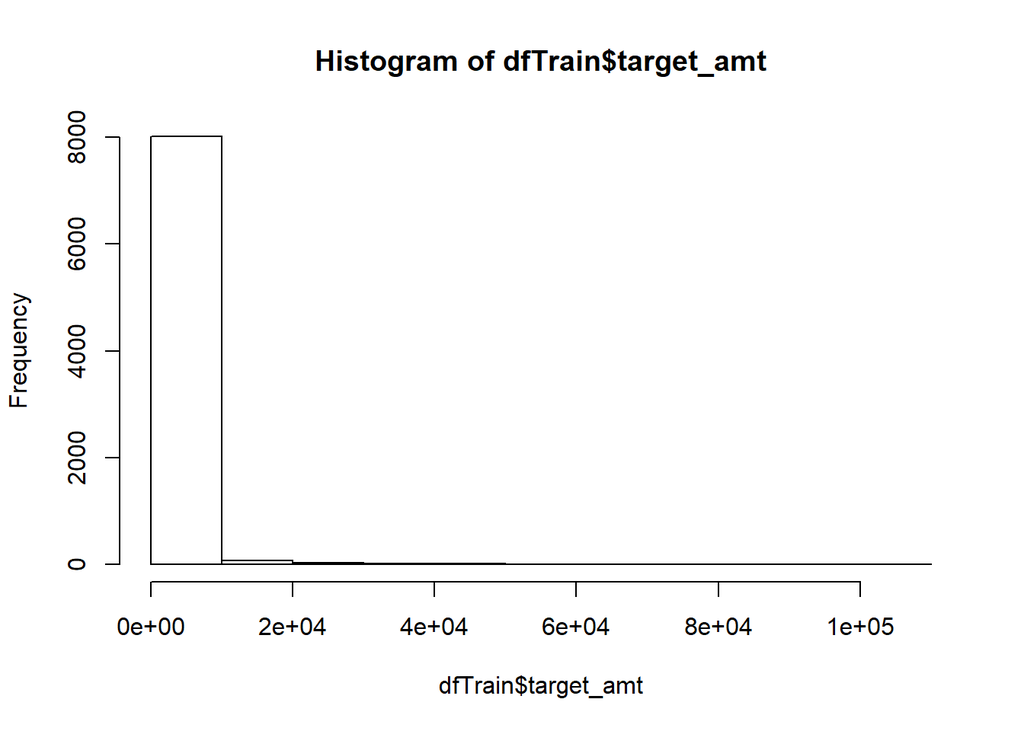

```r
# target flag - proportion
with(dfTrain, prop.table(ftable(target_flag), 1))
## target_flag         0         1
##
##             0.7361843 0.2638157

# target amt - distribution
hist(dfTrain$target_amt)
```

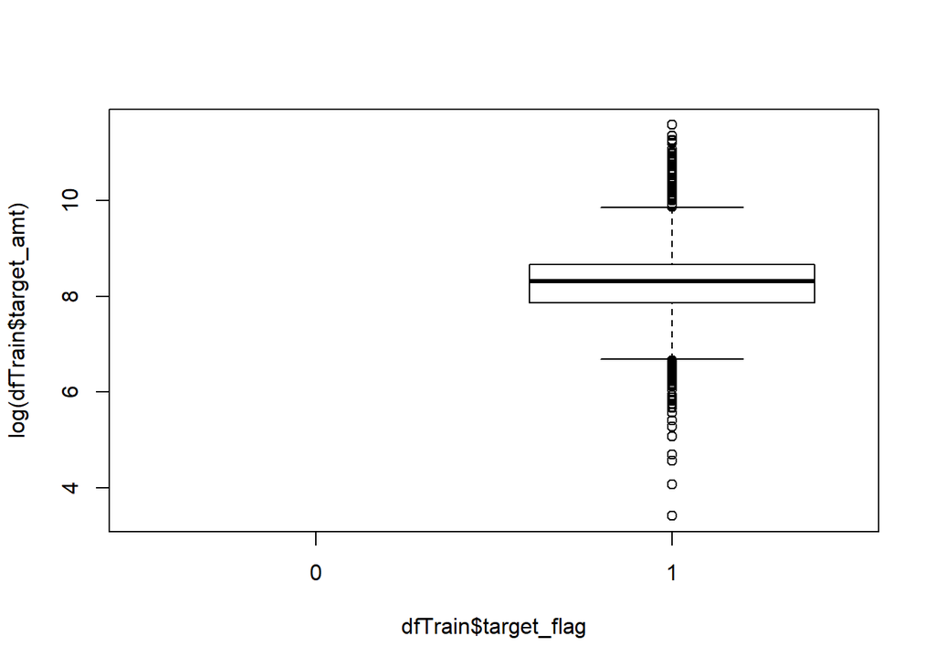

```r
# target amt - log transformed
boxplot(log(dfTrain$target_amt) ~ dfTrain$target_flag)
```

## DATA PREP

```r
# length of unique values of each variable from dfTrain
sapply(dfTrain, function(x) length(unique(x)))
```

```
##       index target_flag  target_amt    kidsdriv         age    homekids
##        8161           2        1949           5          61           6
##         yoj      income     parent1    home_val     mstatus         sex
##          22        6613           2        5107           2           2
##   education         job    travtime     car_use    bluebook         tif
##           5           9          97           2        2789          23
##    car_type     red_car    oldclaim    clm_freq     revoked     mvr_pts
##           6           2        2857           6           2          13
##     car_age  urbanicity
##          31           2
```

```r
# quickly glance at the class of each variable
fields <- data.frame(fields = names(dfTrain),
                     class = sapply(dfTrain, class) %>% unlist %>% as.vector)
fields
```

```
##         fields   class
## 1        index integer
## 2  target_flag integer
## 3   target_amt numeric
## 4     kidsdriv integer
## 5          age integer
## 6     homekids integer
## 7          yoj integer
## 8       income  factor
## 9      parent1  factor
## 10    home_val  factor
## 11     mstatus  factor
## 12         sex  factor
## 13   education  factor
## 14         job  factor
## 15    travtime integer
## 16     car_use  factor
## 17    bluebook  factor
## 18         tif integer
## 19    car_type  factor
## 20     red_car  factor
## 21    oldclaim  factor
## 22    clm_freq integer
## 23     revoked  factor
## 24     mvr_pts integer
## 25     car_age integer
## 26  urbanicity  factor
```

```r
# mutate target_flag
# mutate these 4 factors - "income", "home_val", "bluebook", "oldclaim"
# these should be numeric variables, not factor
dfTrain <- dfTrain %>%
        dplyr::mutate(target_flag = dplyr::case_when(target_flag == 1 ~ "Y",
                                              TRUE ~ "N") %>%
                              factor(., levels = c("Y", "N"), labels = c("Yes", "No")),
                      income = as.numeric(income),
                      home_val = as.numeric(home_val),
                      bluebook = as.numeric(bluebook),
                      oldclaim = as.numeric(oldclaim))

dfEval <- dfEval %>%
        dplyr::mutate(target_flag = dplyr::case_when(target_flag == 1 ~ "Y",
                                              TRUE ~ "N") %>%
                              factor(., levels = c("Y", "N"), labels = c("Yes", "No")),
                      income = as.numeric(income),
                      home_val = as.numeric(home_val),
                      bluebook = as.numeric(bluebook),
                      oldclaim = as.numeric(oldclaim))

# rerun
fields <- data.frame(fields = names(dfTrain),
                     class = sapply(dfTrain, class) %>% unlist %>% as.vector)
fields
```

```
##         fields   class
## 1        index integer
## 2  target_flag  factor
## 3   target_amt numeric
## 4     kidsdriv integer
## 5          age integer
## 6     homekids integer
## 7          yoj integer
## 8       income numeric
## 9      parent1  factor
## 10    home_val numeric
## 11     mstatus  factor
## 12         sex  factor
## 13   education  factor
## 14         job  factor
## 15    travtime integer
## 16     car_use  factor
## 17    bluebook numeric
## 18         tif integer
## 19    car_type  factor
## 20     red_car  factor
## 21    oldclaim numeric
## 22    clm_freq integer
## 23     revoked  factor
## 24     mvr_pts integer
## 25     car_age integer
## 26  urbanicity  factor
```

```r
# set variables
binary_var <- "target_flag"
quant_var <- "target_amt"
variables <- names(dfTrain)[names(dfTrain) %nin% c(binary_var, quant_var, "index")]

# check missing
colSums(is.na(dfTrain))
```

```
##       index target_flag  target_amt    kidsdriv         age    homekids
##           0           0           0           0           6           0
##         yoj      income     parent1    home_val     mstatus         sex
##         454           0           0           0           0           0
##   education         job    travtime     car_use    bluebook         tif
##           0           0           0           0           0           0
##    car_type     red_car    oldclaim    clm_freq     revoked     mvr_pts
##           0           0           0           0           0           0
##     car_age  urbanicity
##         510           0
```

```r
colSums(is.na(dfEval))
```

```
##       index target_flag  target_amt    kidsdriv         age    homekids
##           0           0        2141           0           1           0
##         yoj      income     parent1    home_val     mstatus         sex
##          94           0           0           0           0           0
##   education         job    travtime     car_use    bluebook         tif
##           0           0           0           0           0           0
##    car_type     red_car    oldclaim    clm_freq     revoked     mvr_pts
##           0           0           0           0           0           0
##     car_age  urbanicity
##         129           0
```

```r
# fix missing - train
preProcValuesTrain <- caret::preProcess(dfTrain[, variables], method = c("medianImpute", "center", "scale"))
dfTrain <- predict(preProcValuesTrain, dfTrain)
colSums(is.na(dfTrain))
```

```
##       index target_flag  target_amt    kidsdriv         age    homekids
##           0           0           0           0           0           0
##         yoj      income     parent1    home_val     mstatus         sex
##           0           0           0           0           0           0
##   education         job    travtime     car_use    bluebook         tif
##           0           0           0           0           0           0
##    car_type     red_car    oldclaim    clm_freq     revoked     mvr_pts
##           0           0           0           0           0           0
##     car_age  urbanicity
##           0           0
```

```r
# fix missing - eval
preProcValuesEval <- caret::preProcess(dfEval[, variables], method = c("medianImpute", "center", "scale"))
dfEval <- predict(preProcValuesEval, dfEval)
colSums(is.na(dfEval))
```

```
##       index target_flag  target_amt    kidsdriv         age    homekids
##           0           0        2141           0           0           0
##         yoj      income     parent1    home_val     mstatus         sex
##           0           0           0           0           0           0
##   education         job    travtime     car_use    bluebook         tif
##           0           0           0           0           0           0
##    car_type     red_car    oldclaim    clm_freq     revoked     mvr_pts
##           0           0           0           0           0           0
##     car_age  urbanicity
##           0           0
```

```r
# split data into train (70%), test (30%) sets
set.seed(1234)
index <- caret::createDataPartition(dfTrain$target_flag, p = 0.7, list = FALSE)
trainSet <- dfTrain[index, ]
testSet <- dfTrain[-index, ]

# trainSetControl - let's do 10-fold cross-validation
trainSet.control <- caret::trainControl(method = "cv", number = 10, savePredictions = 'final', classProbs = TRUE)
```

## MODEL - CLASSIFICATION PROBLEM (TARGET_FLAG)

We will first build three classification models and then two multi-linear regression models. Besides logistic regression, let’s try two different classification algorithms, i.e. naivey bayes and random forest. In addition, let’s try to improve our accuracy by 1) doing 10-fold cross-validation, and 2) ensembling our models, i.e. using glm (generalized linear model), nb (naive bayes) and rf (random forest) as our base layer and stacking on top by building a top layer using glm, nb, in addition gbm (gradient boosting machine).

```r
# turn off warning
options(warn = -1)

# count time - start
start <- Sys.time()

# set seed
set.seed(1234)

# methods
baseTrainMethods <- c("glm", "nb", "rf")
topTrainMethods <- c("glm", "nb", "gbm")

# output
modelSummaryList <- vector(mode = "list")

# train base layer
for(baseLayer in baseTrainMethods){

        # set parameters
        ml = baseLayer
        model = paste0("model_base_", ml)
        OOF_prediction = paste0("OOF_pred_", ml)
        prediction = paste0("pred_", ml)
        result = paste0("result_", ml)

        # model
        assign(bquote(.(model)), caret::train(trainSet[, variables], trainSet[, binary_var],
                                              method = ml,
                                              trControl = trainSet.control,
                                              trace = FALSE))

        # Out-Of-Fold probability predictions - trainSet
        if(ml == "glm"){trainSet$OOF_pred_glm = eval(sym(model))$pred$Y[order(eval(sym(model))$pred$rowIndex)]}
        if(ml == "nb"){trainSet$OOF_pred_nb = eval(sym(model))$pred$Y[order(eval(sym(model))$pred$rowIndex)]}
        if(ml == "rf"){trainSet$OOF_pred_rf = eval(sym(model))$pred$Y[order(eval(sym(model))$pred$rowIndex)]}

        # Out-Of-Fold probability predictions - testSet
        assign(bquote(.(OOF_prediction)), predict(eval(sym(model)), testSet[, variables], type = "prob")$Y)
        if(ml == "glm"){testSet$OOF_pred_glm = eval(sym(OOF_prediction))}
        if(ml == "nb"){testSet$OOF_pred_nb = eval(sym(OOF_prediction))}
        if(ml == "rf"){testSet$OOF_pred_rf = eval(sym(OOF_prediction))}

        # Y/N predictions for Confusion Matrix - testSet
        assign(bquote(.(prediction)), predict(eval(sym(model)), testSet[, variables]))
        if(ml == "glm"){testSet$pred_glm = eval(sym(prediction))}
        if(ml == "nb"){testSet$pred_nb = eval(sym(prediction))}
        if(ml == "rf"){testSet$pred_rf = eval(sym(prediction))}

        # output
        assign(bquote(.(result)), broom::tidy(caret::confusionMatrix(testSet[, prediction], testSet[, binary_var])) %>%
                       dplyr::mutate(trainMethod = ml) %>%
                       dplyr::select(trainMethod, everything()))

        # store output into a list
        tempModelList <- list(eval(sym(result)))
        modelSummaryList <<- c(modelSummaryList, tempModelList)

}

# train top layer
for(topLayer in topTrainMethods){

        # set parameters
        ml = topLayer
        model = paste0("model_top_", ml)
        OOF_predictors_top = c("OOF_pred_glm", "OOF_pred_nb", "OOF_pred_rf")
        OOF_prediction_top = paste0("OOF_pred_top_", ml)
        prediction_top = paste0("pred_top_", ml)
        result = paste0("result_top_", ml)

        # model
        assign(bquote(.(model)), caret::train(trainSet[, OOF_predictors_top], trainSet[, binary_var],
                                              method = ml,
                                              trControl = trainSet.control))

        # Out-Of-Fold probability predictions - testSet
        assign(bquote(.(OOF_prediction_top)), predict(eval(sym(model)), testSet[, OOF_predictors_top], type = "prob")$Y)
        if(ml == "glm"){testSet$OOF_pred_top_glm = eval(sym(OOF_prediction_top))}
        if(ml == "nb"){testSet$OOF_pred_top_nb = eval(sym(OOF_prediction_top))}
        if(ml == "gbm"){testSet$OOF_pred_top_gbm = eval(sym(OOF_prediction_top))}

        # Y/N predictions for Confusion Matrix - testSet
        assign(bquote(.(prediction_top)), predict(eval(sym(model)), testSet[, OOF_predictors_top]))
        if(ml == "glm"){testSet$pred_top_glm = eval(sym(prediction_top))}
        if(ml == "nb"){testSet$pred_top_nb = eval(sym(prediction_top))}
        if(ml == "gbm"){testSet$pred_top_gbm = eval(sym(prediction_top))}

        # output
        assign(bquote(.(result)), broom::tidy(caret::confusionMatrix(testSet[, prediction_top], testSet[, binary_var])) %>%
                       dplyr::mutate(trainMethod = paste0(ml, " - top layer")) %>%
                       dplyr::select(trainMethod, everything()))

        # store output into a list
        tempModelList <- list(eval(sym(result)))
        modelSummaryList <<- c(modelSummaryList, tempModelList)

}

# put together - averaging the OOF prediction probability
testSet <- testSet %>%
        dplyr::mutate(pred_final_prob_avg = (OOF_pred_top_glm + OOF_pred_top_nb + OOF_pred_top_gbm) / length(topTrainMethods),
                      pred_final = ifelse(pred_final_prob_avg > 0.5, "Y", "N") %>%
                              factor(., levels = c("Y", "N"), labels = c("Yes", "No")))

finalResult <- broom::tidy(caret::confusionMatrix(testSet$pred_final, testSet$target_flag)) %>%
        dplyr::mutate(trainMethod = "final - averaging") %>%
        dplyr::select(trainMethod, everything())

# store finalResult output into a list
tempModelList <- list(finalResult)
modelSummaryList <<- c(modelSummaryList, tempModelList)

# count time - finish
finish <- Sys.time()
```